# Latent Class Analysis

# Latent Class Analysis

## Can There Really Be More Latent Stuff?

We have covered a big slice of models that deal with some type of latent structure. Latent class analysis (LCA) differs from what we have previously seen. In factor analysis, for example, we are finding the latent variables that give cause to the measured items. LCA, on the other hand, attempts to use variables to find latent classes of people. For example, if we have variables regarding race, gender, education, and employment status, can we find naturally occuring groups that cluster together?

## LCA

LCA has definite conceptual relationships to cluster analysis and factor analysis. From a technical standpoint, however, they are different. While we saw that certain variable types work better for different types of cluster analyses, categorical variables are the only variables that can be used in LCA (e.g., it could not use raw age – you would unfortuantely need to discretize it first). The latent classes that emerge in LCA are often noted as “profiles” (some people even call it latent profile analysis) – thinking of them as profiles allows you to think about constructing general profiles and grouping people into those profiles.

Let’s try to fit a model with 2 latent classes based upon education, gender, and party identification. We can use the election data from poLCA.

```r
library(poLCA)
library(dplyr)
data("election")

lcaDat = election

lcaFormula = cbind(EDUC, GENDER, PARTY) ~ 1

lcaMod2 = poLCA(lcaFormula, lcaDat, 2, maxiter = 5000)
```

```
## Conditional item response (column) probabilities,
##  by outcome variable, for each class (row)
##
## $EDUC
##            Pr(1)  Pr(2)  Pr(3)  Pr(4)  Pr(5)  Pr(6)  Pr(7)
## class 1:  0.0445 0.0838 0.3899 0.2046 0.0995 0.1302 0.0474
## class 2:  0.0182 0.0272 0.1472 0.2196 0.0863 0.3223 0.1793
##
## $GENDER
##            Pr(1)  Pr(2)
## class 1:  0.3374 0.6626
## class 2:  0.5809 0.4191
##
## $PARTY
##            Pr(1)  Pr(2)  Pr(3)  Pr(4)  Pr(5)  Pr(6)  Pr(7)
## class 1:  0.2304 0.2139 0.1624 0.1673 0.0888 0.0768 0.0604
## class 2:  0.1472 0.0715 0.1362 0.0357 0.1895 0.1832 0.2367
##
## Estimated class population shares
##  0.5862 0.4138
##
## Predicted class memberships (by modal posterior prob.)
##  0.608 0.392
##
## =========================================================
## Fit for 2 latent classes:
## =========================================================
## number of observations: 1755
## number of estimated parameters: 27
## residual degrees of freedom: 70
## maximum log-likelihood: -7628.878
##
## AIC(2): 15311.76
## BIC(2): 15459.45
## G^2(2): 89.21528 (Likelihood ratio/deviance statistic)
## X^2(2): 86.54739 (Chi-square goodness of fit)
##
```

Our output is showing us our two classes, as we specified, and the probabilities of each variables response category belonging to a class. This will be explained in more depth shortly. The output also gives us our estimated population shares (how many are observed) and the predicted class membership (how many would be predicted).

We also get some fit statistics and those are interpreted as we would normally expect.

Seeing a plot of the class probabilities will be helpful as an explanatory tool and the help for the election data is critical for knowing what the levels are within the data:

EDUC is 1 (8th grade or less) through 7 (advanced degree), gender is 1 (male), and party is 1 (strong Democrat) to 7 (strong Republican).

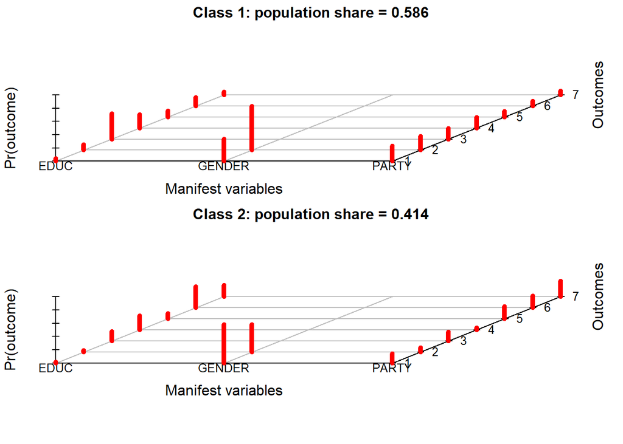

```r
plot(lcaMod2)
```

One interesting thing about LCA is that an automated class selection mechanism really does not exist – you need to engage in some model comparison.

Let’s try models with 3, 4, and 5 classes.

```r
lcaMod3 = poLCA(lcaFormula, lcaDat, 3, maxiter = 5000)
```

```
## Conditional item response (column) probabilities,
##  by outcome variable, for each class (row)
##
## $EDUC
##            Pr(1)  Pr(2)  Pr(3)  Pr(4)  Pr(5)  Pr(6)  Pr(7)
## class 1:  0.0674 0.0919 0.2849 0.1904 0.1143 0.1785 0.0725
## class 2:  0.0000 0.0544 0.5894 0.2477 0.0561 0.0524 0.0000
## class 3:  0.0220 0.0339 0.1090 0.2076 0.0979 0.3364 0.1930
##
## $GENDER
##            Pr(1)  Pr(2)
## class 1:  0.3583 0.6417
## class 2:  0.3347 0.6653
## class 3:  0.5784 0.4216
##
## $PARTY
##            Pr(1)  Pr(2)  Pr(3)  Pr(4)  Pr(5)  Pr(6)  Pr(7)
## class 1:  0.3086 0.3448 0.0788 0.1241 0.0000 0.1438 0.0000
## class 2:  0.1423 0.0639 0.2465 0.2046 0.1846 0.0220 0.1361
## class 3:  0.1213 0.0293 0.1628 0.0455 0.2221 0.1596 0.2593
##
## Estimated class population shares
##  0.3721 0.2394 0.3886
##
## Predicted class memberships (by modal posterior prob.)
##  0.4177 0.2068 0.3755
##
## =========================================================
## Fit for 3 latent classes:
## =========================================================
## number of observations: 1755
## number of estimated parameters: 41
## residual degrees of freedom: 56
## maximum log-likelihood: -7617.268
##
## AIC(3): 15316.54
## BIC(3): 15540.82
## G^2(3): 65.99626 (Likelihood ratio/deviance statistic)
## X^2(3): 62.37514 (Chi-square goodness of fit)
##
## ALERT: iterations finished, MAXIMUM LIKELIHOOD NOT FOUND
##
```

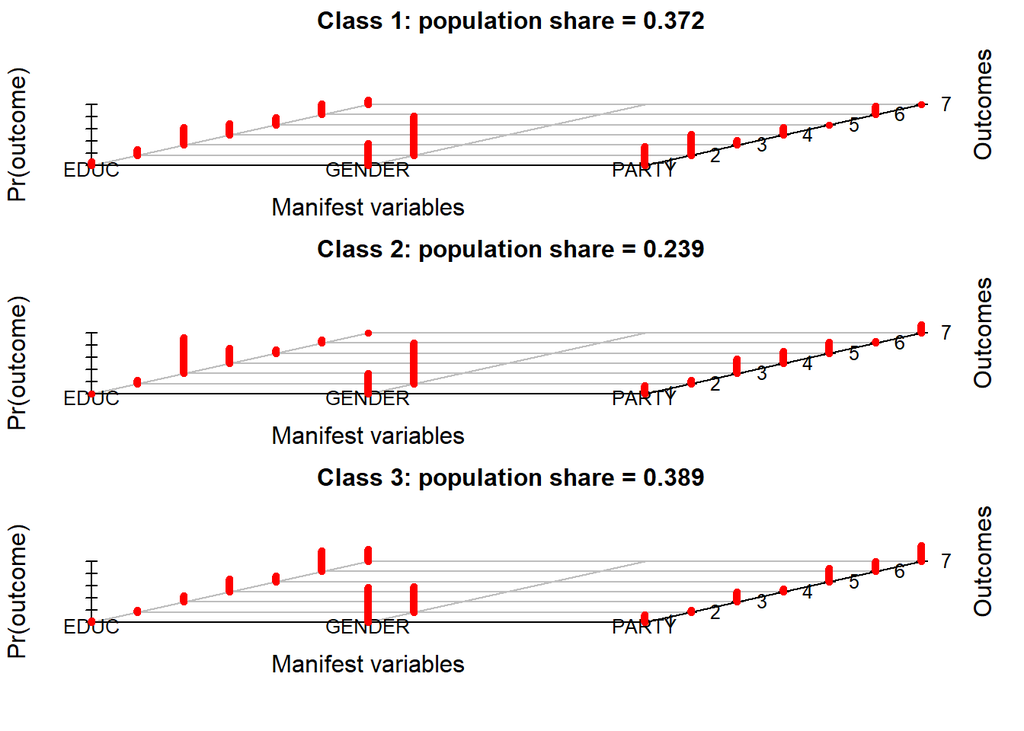

```r
plot(lcaMod3)
```

```r
lcaMod4 = poLCA(lcaFormula, lcaDat, 4, maxiter = 5000)
```

```
## Conditional item response (column) probabilities,
##  by outcome variable, for each class (row)
##
## $EDUC
##            Pr(1)  Pr(2)  Pr(3)  Pr(4)  Pr(5)  Pr(6)  Pr(7)
## class 1:  0.1639 0.1330 0.1808 0.0547 0.2288 0.1251 0.1137
## class 2:  0.0000 0.0000 0.0037 0.2239 0.1350 0.4073 0.2300
## class 3:  0.0000 0.0652 0.5339 0.2625 0.0438 0.0946 0.0000
## class 4:  0.1957 0.2135 0.4162 0.0789 0.0000 0.0422 0.0534
##
## $GENDER
##            Pr(1)  Pr(2)
## class 1:  0.0000 1.0000
## class 2:  0.5766 0.4234
## class 3:  0.3245 0.6755
## class 4:  1.0000 0.0000
##
## $PARTY
##            Pr(1)  Pr(2)  Pr(3)  Pr(4)  Pr(5)  Pr(6)  Pr(7)
## class 1:  0.3031 0.3709 0.0901 0.0987 0.0296 0.1076 0.0000
## class 2:  0.1560 0.1038 0.1374 0.0563 0.1720 0.1609 0.2136
## class 3:  0.1882 0.1657 0.1757 0.1604 0.1265 0.0716 0.1119
## class 4:  0.2789 0.0450 0.1673 0.1325 0.0959 0.2207 0.0596
##
## Estimated class population shares
##  0.1078 0.3712 0.4396 0.0815
##
## Predicted class memberships (by modal posterior prob.)
##  0.0764 0.4376 0.433 0.053
##
## =========================================================
## Fit for 4 latent classes:
## =========================================================
## number of observations: 1755
## number of estimated parameters: 55
## residual degrees of freedom: 42
## maximum log-likelihood: -7601.741
##
## AIC(4): 15313.48
## BIC(4): 15614.34
## G^2(4): 34.94148 (Likelihood ratio/deviance statistic)
## X^2(4): 34.35938 (Chi-square goodness of fit)
##
## ALERT: iterations finished, MAXIMUM LIKELIHOOD NOT FOUND
##
```

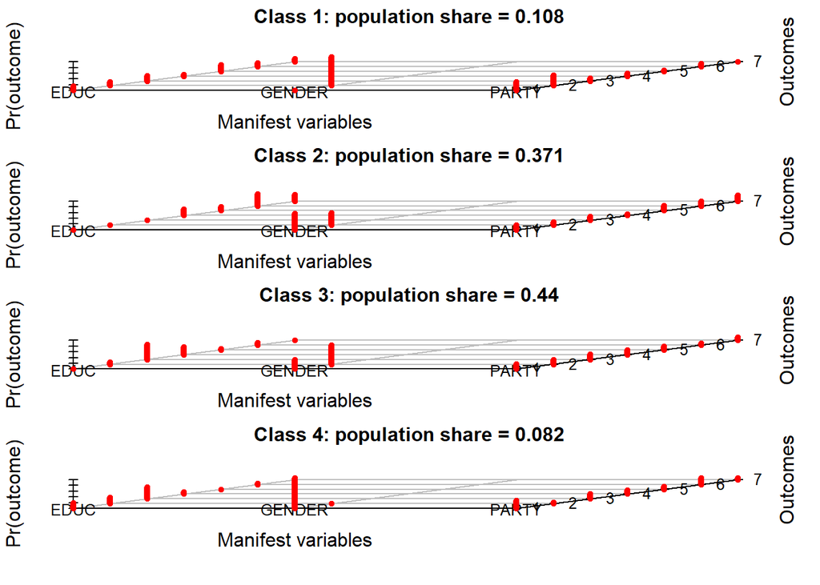

```r
plot(lcaMod4)
```

```r
lcaMod5 = poLCA(lcaFormula, lcaDat, 5, maxiter = 5000)
```

```
## Conditional item response (column) probabilities,
##  by outcome variable, for each class (row)
##
## $EDUC
##            Pr(1)  Pr(2)  Pr(3)  Pr(4)  Pr(5)  Pr(6)  Pr(7)
## class 1:  0.0000 0.0000 0.0000 0.1768 0.0899 0.3917 0.3416
## class 2:  0.0000 0.0435 0.2189 0.2812 0.1455 0.2930 0.0178
## class 3:  0.1920 0.2198 0.4563 0.1135 0.0008 0.0177 0.0000
## class 4:  0.1585 0.1462 0.3506 0.0324 0.1510 0.0128 0.1484
## class 5:  0.0000 0.0469 0.4682 0.2707 0.0701 0.1442 0.0000
##
## $GENDER
##            Pr(1)  Pr(2)
## class 1:  0.6589 0.3411
## class 2:  0.3911 0.6089
## class 3:  1.0000 0.0000
## class 4:  0.0000 1.0000
## class 5:  0.3235 0.6765
##
## $PARTY
##            Pr(1)  Pr(2)  Pr(3)  Pr(4)  Pr(5)  Pr(6)  Pr(7)
## class 1:  0.1771 0.0494 0.1674 0.0595 0.2130 0.1275 0.2062
## class 2:  0.1144 0.3314 0.0047 0.0128 0.0297 0.2923 0.2146
## class 3:  0.2807 0.0536 0.1729 0.1378 0.0912 0.2121 0.0517
## class 4:  0.3287 0.3429 0.1009 0.0950 0.0349 0.0977 0.0000
## class 5:  0.1959 0.0858 0.2393 0.2081 0.1741 0.0000 0.0968
##
## Estimated class population shares
##  0.2392 0.2114 0.0831 0.1114 0.3549
##
## Predicted class memberships (by modal posterior prob.)
##  0.2348 0.212 0.0764 0.0957 0.3812
##
## =========================================================
## Fit for 5 latent classes:
## =========================================================
## number of observations: 1755
## number of estimated parameters: 69
## residual degrees of freedom: 28
## maximum log-likelihood: -7595.542
##
## AIC(5): 15329.08
## BIC(5): 15706.53
## G^2(5): 22.5444 (Likelihood ratio/deviance statistic)
## X^2(5): 22.13637 (Chi-square goodness of fit)
##
## ALERT: iterations finished, MAXIMUM LIKELIHOOD NOT FOUND
##
```

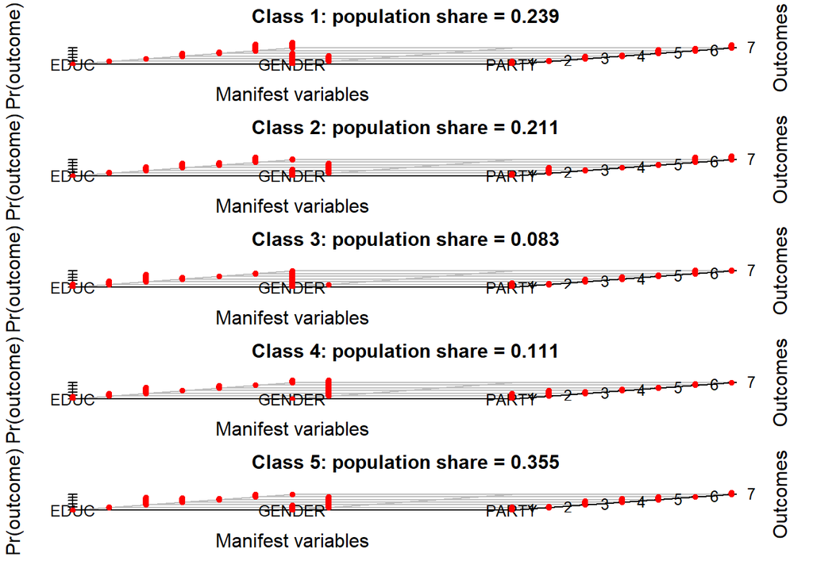

```r
plot(lcaMod5)
```

Using each model’s AIC, let’s see which model might work the best:

```r
rbind(class2 = lcaMod2$aic,
      class3 = lcaMod3$aic,
      class4 = lcaMod4$aic,
      class5 = lcaMod5$aic)
```

```
##            [,1]
## class2 15311.76
## class3 15316.54
## class4 15313.48
## class5 15329.08
```

There is not too much difference between 2 and 3 classes, so we could stick with parsimony and be happy with 2 classes.

Latent class analysis will also let us include a covariate in our model, essentially performing a regression. Let’s define a latent class based upon views of presidential candidates (demarked by a B or G after the variable name):

```r
covariateFormula = cbind(LEADG, MORALG, LEADB, MORALB) ~ PARTY

intelPartyLCA = poLCA(covariateFormula, lcaDat, 2, maxiter = 5000)
```

```
## Conditional item response (column) probabilities,
##  by outcome variable, for each class (row)
##
## $LEADG
##           1 Extremely well 2 Quite well 3 Not too well 4 Not well at all
## class 1:            0.2524       0.5765         0.1476            0.0234
## class 2:            0.0118       0.2264         0.5240            0.2379
##
## $MORALG
##           1 Extremely well 2 Quite well 3 Not too well 4 Not well at all
## class 1:            0.3821       0.5261         0.0736            0.0182
## class 2:            0.0935       0.4234         0.3116            0.1716
##
## $LEADB
##           1 Extremely well 2 Quite well 3 Not too well 4 Not well at all
## class 1:            0.0621       0.4034         0.3756            0.1590
## class 2:            0.3013       0.6316         0.0575            0.0096
##
## $MORALB
##           1 Extremely well 2 Quite well 3 Not too well 4 Not well at all
## class 1:            0.1016       0.4847         0.3178            0.0960
## class 2:            0.3621       0.5576         0.0687            0.0117
##
## Estimated class population shares
##  0.569 0.431
##
## Predicted class memberships (by modal posterior prob.)
##  0.5696 0.4304
##
## =========================================================
## Fit for 2 latent classes:
## =========================================================
## 2 / 1
##             Coefficient  Std. error  t value  Pr(>|t|)
## (Intercept)    -5.65737     0.45270  -12.497         0
## PARTY           1.32879     0.10246   12.969         0
## =========================================================
## number of observations: 1459
## number of estimated parameters: 26
## residual degrees of freedom: 229
## maximum log-likelihood: -6438.342
##
## AIC(2): 12928.68
## BIC(2): 13066.11
## X^2(2): 3273.341 (Chi-square goodness of fit)
##
```

To start, we are comparing the likelihood that a person will belong to class 2 as opposed to class 1 (that is what the 2 / 1 indicates). If we use our PARTY scores with our provided equation, we will get at the log-ratio prior probability:

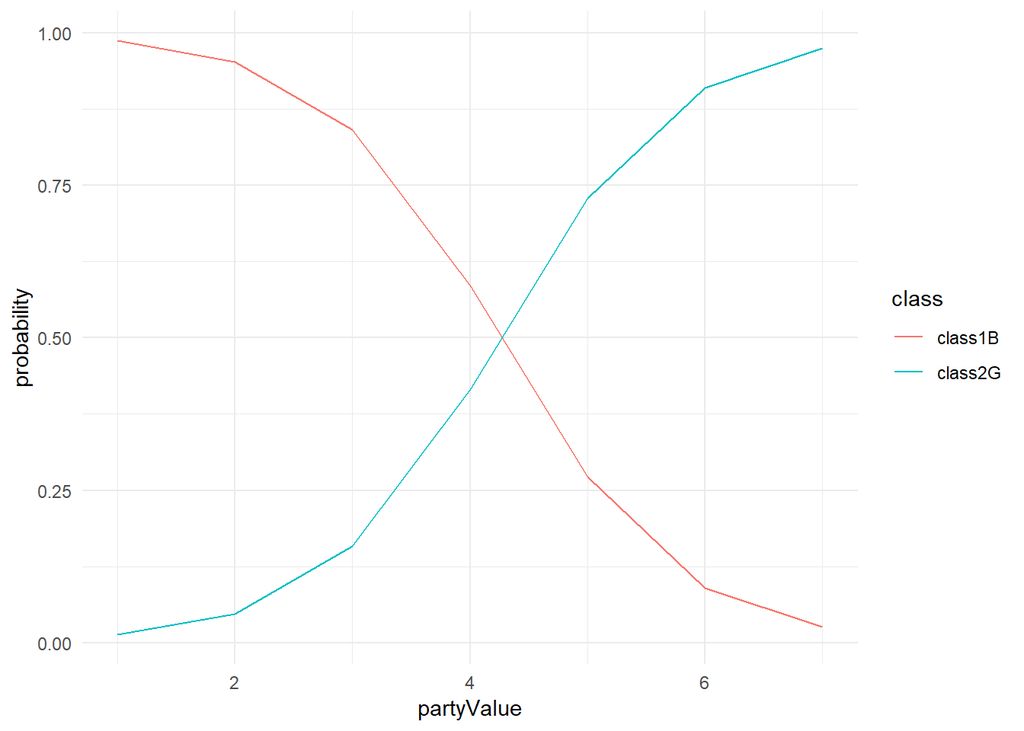

```r
classPriors = exp(cbind(1, c(1:7)) %*% intelPartyLCA$coeff)

priorProbs = cbind(1, classPriors) / (1 + rowSums(classPriors))

priorProbsData = data.frame(class1B = priorProbs[, 1],
                           class2G = priorProbs[, 2],
                           partyValue = 1:7) %>%
  tidyr::gather(.,key = class, value = probability, -partyValue)

library(ggplot2)

ggplot(priorProbsData, aes(x = partyValue, y = probability, color = class)) +
  geom_line() +
  theme_minimal()
```

Using this added feature of latent class analysis can help to make more sense of the classes and give you a better idea about how people within those classes might behave.